# Gender Prediction Methods Based on First Names with genderizeR

### 4.3 Case study 2: Titles of biographical articles

As in the first case study, we can train the algorithm on the second dataset with titles of biographical articles, using a wider set of values for both `probs` and `counts` parameters. In the case of a huge parameter grid, we can also try to run the `genderizeTrain` function in parallel version (see `parallel` argument).

```r
R> probs <- seq(from = 0.5, to = 0.9, by = 0.05)
R> probs <- c(probs, seq(from = 0.91, to = 1, by = 0.01))
R> counts <- seq(from = 1, to = 16, by = 1)
R> titlesGrid <-
+    genderizeTrain(# parallel = TRUE,
+                   x = titles$title,
+                   y = titles$genderCoded,
+                   givenNamesDB = givenNamesDB_titles,
+                   probs = probs,
+                   counts = counts)
```

Because the scatterplot for all parameter combinations would be very unclear, we have visualised only a subset of count values: 1, 4, 7 (Figure 2). The trends and patterns that emerged from such a simplified visualisation are similar to other combinations of parameters.

Parameter values `prob = 0.70` and `count = 1` minimised coded error rate for this dataset produced a reasonable low gender bias error rate. We can also achieve lower gender bias error rate; however, it comes with an increased proportion of unpredicted items.

```r
R> titlesGrid[titlesGrid$errorCoded == min(titlesGrid$errorCoded), ]

   prob count errorCoded errorCodedWithoutNA    naCoded errorGenderBias
1:  0.7     1  0.1004367          0.06533575 0.03755459      0.02540835
R> titlesGrid[titlesGrid$errorGenderBias ==
+             min(abs(titlesGrid$errorGenderBias)), ]

   prob count errorCoded errorCodedWithoutNA   naCoded errorGenderBias
1:    1    15  0.2917031          0.04023669 0.2620087     0.002366864
2:    1    16  0.2917031          0.04023669 0.2620087     0.002366864
```

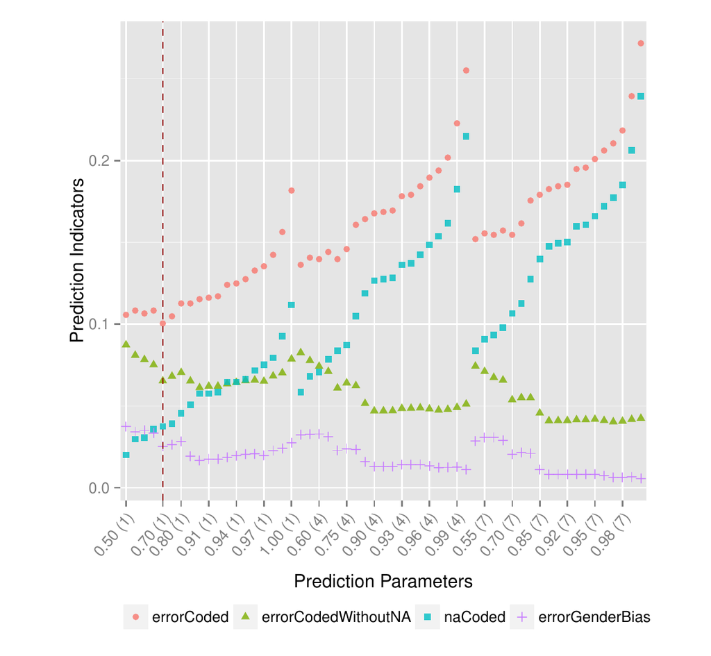

Figure 2: Effectiveness of gender prediction for given parameters from the title sample. The lowest `errorCoded` is achieved with probability = 0.70 and count = 1 (marked on the plot as a dashed red line), which also yields resonable low values of other error rates. The proportion of items with unpredicted gender (`naCoded`) increases periodically with the increase of the parameter values. The gender bias error rate (`errorGenderBias`) could be minimised at the cost of increasing the proportion of items with unpredicted gender. The final decision on which set of parameter values to use can be subjective and is dependent on the importance of each indicator in a given analysis.

The final decision on which set of parameter values to use can be subjective and is dependent on the importance of each indicator in a given analysis.

## 5 Further estimation of prediction accuracy

For further estimation of gender prediction accuracy we can use cross-validation or bootstrap methods like *Leave-One-Out Bootstrap* (LOO) (Efron 1983) and *.632+ Rule* (Efron and Tibshirani 1997) as well as *Receiver Operating Characteristic* (ROC) and *Area Under Curve* (AUC) (Fawcett 2003) or finally *Brier Score* (Brier 1950) as one of the most popular performance metrics for probabilistic classifiers.

### 5.1 Bootstrapping

Up to this moment, we have only relied on the so called *apparent error rate*, which is *the observed inaccuracy of the fitted model to the original data points*. However, the apparent error rate usually underestimates the true error rate and gives a falsely optimistic picture of the model’s true accuracy (Efron 1986). To address this issue, we can calculate the *Leave-One-Out (LOO) bootstrap error rate* proposed by Efron (1983).

In the LOO bootstrap procedure, we generate some number of bootstrap samples of the size of the original sample. On each bootstrap sample, we can train our prediction algorithm by minimising the classification error. Later, we can use optimal parameters to predict gender for items that have not been sampled in this particular bootstrap sample. This way, we avoid testing a prediction model on the items used for choosing the prediction parameters.

As Jiang and Simon (2007) summarised, the LOO bootstrap is a smoothed version of the LOO cross-validation. Bootstrap samples differentiate among each other more than the original LOO sets. Moreover, for each item, the LOO bootstrap method averages the errors from the multiple predictions made on the bootstrap samples. As a result, the LOO bootstrap estimate has a much smaller variability than the LOO cross-validation estimate.

On the other hand, in contrast to low bias cross-validation, the LOO bootstrap in some cases presents noticeable bias and tends to overestimate the true prediction error. The *.632+* estimator was proposed as a remedy to deal with this problem (Efron and Tibshirani 1997).

In gender prediction, we can use these bootstrap methods, as they are implemented in *genderizeR* package in the `genderizeBootstrapError` function.

We can still train our prediction algorithm on a large grid of parameters, or we can focus on combinations that we suspect could yield different outcomes on different bootstrap samples. In our `titles` dataset, we found that parameters `prob >= 0.70` and `count >= 1` give us the lowest apparent error rate on coded items, but it is reasonable to suspect that the combination of `prob >= 0.50` and `count >= 1` also could give us the lowest error rate on some random samples.

```r
R> counts <- 1
R> probs <- c(0.5, 0.7)
R> set.seed(42)
R> bootstrapErrors <- genderizeBootstrapError(
+    # parallel = TRUE,
+    x = titles[titles$genderCoded %in% c('female', 'male')]$title,
+    y = titles[titles$genderCoded %in% c('female','male')]$genderCoded,
+    givenNamesDB = givenNamesDB_titles,
+    probs = probs,
+    counts = counts,
+    num_bootstraps = 50)
R> t(as.data.frame(bootstrapErrors))

                      [,1]
apparent         0.1004367
loo_boot         0.1037184
errorRate632plus 0.1025251
```

All bootstrap errors are calculated only on items with gender labels and predictions. The `apparent` value presents the underestimated *apparent error rate*; the `loo_boot` value provides the overestimated *LOO bootstrap error rate* and the `errorRate632plus` value gives *.632+* estimator that provides the best estimation of prediction error rate.

### 5.2 ROC and AUC

In order to plot the ROC curve or calculate AUC (Fawcett 2003) for our predictions on the `title` sample, we can use the R package [*ROCR*](https://CRAN.R-project.org/package=ROCR) (Sing et al. 2005), but the datasets need to be prepared first. We need to have a data frame that shows which title has manually coded female (or male) gender types with a column of corresponding probabilities predicting these genders. To do that, we need to combine the original dataset with the prediction and corresponding gender data.

```r
R> genderizedTitles_output <-  genderize(x = titles[['title']],
+                                        genderDB = givenNamesDB_titles,
+                                        progress = FALSE)
R> genderizedTitles <- cbind(as.data.frame(titles),
+                            as.data.frame(genderizedTitles_output))
R> genderizedTitles <-
+    left_join(x = genderizedTitles[, names(genderizedTitles) != 'gender'],
+              y = givenNamesDB_titles, by = c("givenName" = "name"))
R> example <- rownames(genderizedTitles[c(3, 9, 25, 27, 29, 37), ])
R> genderizedTitles %>%
+    dplyr::select(title, genderCoded, givenName,
+    probability, count, gender) %>%
+    filter(rownames(.) %in% example)

                                                                    title
1                       (Jacqueline) Nancy Mary Adams, CBE, QSO 1926-2007
2                                 2005 R W P King Award - Robert J. Adams
3                                       A master potter (Josiah Wedgwood)
4 A musician without retirement - Claus Bantzer ceases and makes it again
5                    A pioneer in the world of advertising, Armando Testa
6                                       A tribute to Jean-Michel Quinodoz
  genderCoded givenName probability  count gender
1      female      mary        1.00  54051 female
2        male    robert        1.00 100216   male
3        male    josiah        0.98     43   male
4        male     claus        0.94     81   male
5        male   armando        0.99    329   male
6        male      jean        0.52  26799   male
```

In the next step, we can compute our vector of probabilities that we use to predict a given gender for each item.

```r
R> d <- genderizedTitles
R> d[is.na(d[['gender']]), ][['gender']] <- 'unknown'
R> d <- d[d[['genderCoded']] %in% c('female', 'male', 'unknown' ), ]
R> d <- d[d[['gender']]  %in% c('female', 'male', 'unknown' ), ]
R> d$labels <- ifelse(d[['genderCoded']] == 'female', 1, 0)
R> d$pred <- ifelse(d[['gender']] == 'female',
+                   as.numeric(d[['probability']]),
+                   1-as.numeric(d[['probability']]))
R> d %>% dplyr::select(title, genderCoded, labels, pred) %>%
+    filter(rownames(.) %in% example)

                                                                    title
1                       (Jacqueline) Nancy Mary Adams, CBE, QSO 1926-2007
2                                 2005 R W P King Award - Robert J. Adams
3                                       A master potter (Josiah Wedgwood)
4 A musician without retirement - Claus Bantzer ceases and makes it again
5                    A pioneer in the world of advertising, Armando Testa
6                                       A tribute to Jean-Michel Quinodoz
  genderCoded labels pred
1      female      1 1.00
2        male      0 0.00
3        male      0 0.02
4        male      0 0.06
5        male      0 0.01
6        male      0 0.48
```

Now we can plot the ROC curve and calculate the AUC.

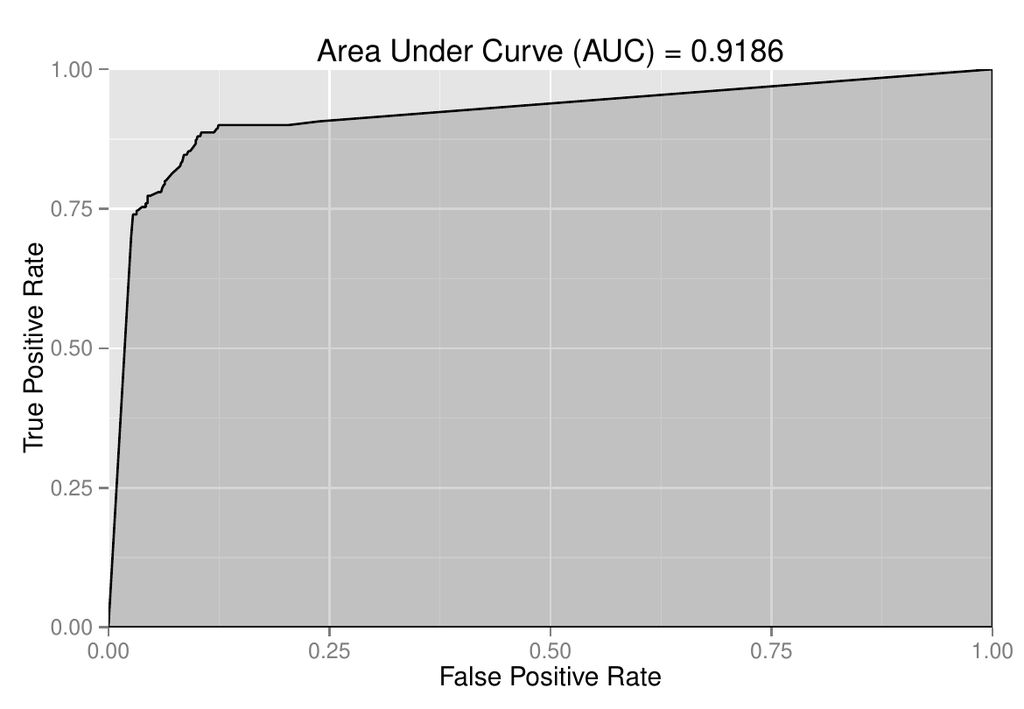

Figure 3: ROC curve for predicting female gender for the `titles` dataset. Large AUC suggests good prediction accuracy.

```r
R> library('ROCR')
R> pred <- prediction(labels = d[['labels']], predictions = d[['pred']])
R> perf <- performance(pred, measure = 'tpr', x.measure = 'fpr')
R> # area under the curve (AUC)
R> unlist(performance(pred, measure = 'auc')@y.values)

[1] 0.9186008
```

The AUC value is high (0.92), so we can conclude that the gender prediction algorithm performs well on this sample dataset. We can also treat the AUC measure as a general measure of predictiveness (Fawcett 2003) and use it for comparison of different prediction methods.

### 5.3 Brier Score

Classification errors can be misleading metrics of gender prediction effectiveness, especially in the case when we have a great disproportion of female and male labels in the dataset. For example, in our `titles` dataset we have 87% male titles. If we predict male for each item in the dataset, our classification error will be only 13% due to small true proportion of female items.

```r
R> titlesCoded <- titles[titles[['genderCoded']] %in% c('female', 'male'), ]
R> cbind('N' = table(titlesCoded[['genderCoded']]),
+        '%' = round(prop.table(table(titlesCoded[['genderCoded']])) * 100, 0))

         N  %
female 151 13
male   994 87
R> indicators <-
+    classificationErrors(labels = titlesCoded[['genderCoded']],
+                         predictions = rep('male',
+                                           NROW(titlesCoded[['genderCoded']])))
R> unlist(indicators['errorCoded'])

errorCoded
 0.1318777
```

Predicting the most frequent class on every occasion in order to minimise the classification error rate is not an appropriate scoring rule and the prediction efficiency metrics should be penalised for such practices. That is why we use the *Brier Score*, which originated from a verification system of weather forecasts (Brier 1950) and is known as a more proper classification accuracy score for predictions based on probabilities.

The *Brier Score* was defined as the sum of squared differences between `labels` values (ex. 1 if an item is a female and 0 if it is not) and `pred` values (probability if an item is a female) divided by the number of all items. The R package [*verification*](https://CRAN.R-project.org/package=verification) (NCAR – Research Applications Laboratory 2014) offers an implementation of the *Brier Score* in the `brier` function.

```r
R> library('verification')
R> brier(obs = d[['labels']], pred =  d[['pred']])[['bs']]

[1] 0.06577986
```

If an item’s gender is correctly predicted with probability equal to 1, then the *Brier Score* is 0, and this is the best possible score. The worst score is 1.

We can also calculate presented and other metrics using a simulated bogus prediction algorithm. Such algorithm predicts the majority class (male labels) for all items. Both AUC and *Brier Score* are penalised since the bogus algorithm has just been guessing the gender using the most frequent class in this sample dataset.

```r
R> pred <- prediction(labels = d[['labels']],
+                     predictions = rep(0, NROW(d[['labels']])))
R> unlist(performance(pred, measure = 'auc')@y.values)

[1] 0.5
R> brier(obs = d[['labels']],
+        pred = rep(0, NROW(d[['labels']])))[['bs']]

[1] 0.12119
```

To compare different approaches of gender prediction, we need to reproduce those methods on the same sample that is drawn from the population of items with similar characteristics. We use an `authorships` dataset as such a sample, since predicting the gender of authors of the articles was the goal of two previously described studies.

Because the US SSA and the US Census data is available in the R packages, we can easily reproduce methods based on such data with parameters that were chosen by the authors of the studies. However, in the case of the method described by Larivière et al. (2013b), we can only reproduce gender prediction utilising the US Census data. Scraping and parsing other webpages or manually coding gender are highly resource intensive and our goal is to find a resource effective method. Nevertheless, we can later reproduce a confusion matrix from the study and try to estimate the real error for this mixed method.

The efficiency indicators of gender prediction for all three methods are presented in Table 3. For the third proposed method, we had not extracted first names from the authors’ full names, and we let the `findGivenNames` function try to do this automatically.

Table 3: Comparison of the effectiveness of gender prediction methods.

| Characteristics of prediction methods and prediction efficiency indicators | West et al. (2013) | Larivière et al. (2013) | *genderizeR* package |
| --- | --- | --- | --- |
| Source of first names data | US SSA | US Census | genderize.io |
| Extracted full first names | Yes | Yes | No |
| Gender probability threshold | 0.95 | 0.91 | 0.50 |
| Names count threshold | 5 | 7200 | 1 |
| Classification error rates (%): |  |  |  |
| coded error rate | 32.49 | 36.84 | 7.09 |
| coded error rate without NA values | 1.67 | 2.13 | 3.79 |
| net gender bias error | 1.67 | 2.13 | 1.42 |
| Accuracy scores: |  |  |  |
| AUC | 0.926 | 0.920 | 0.927 |
| Brier Score | 0.099 | 0.109 | 0.097 |
| Unpredicted gender (%): |  |  |  |
| of all authorships | 84.40 | 85.23 | 47.71 |
| of authorships with full first names | 31.56 | 35.22 | 4.65 |
| of manually coded gender only | 31.35 | 35.47 | 3.43 |

It should be noted that using data sources other than the US Census with manual coding as done by Larivière et al. (2013b) would probably improve the proportion of items with predicted gender in our sample. However, it is difficult to assess the effectiveness of such a resource-consuming mixed method without comparable prediction metrics. The authors did not explicitly present the confusion matrix from their validation study, but we can recreate the matrix using materials from the analysed studies, such as Table S3 *Number and percentage of distinct papers and of author-papers assigned a gender* and Table S6 *Percent male and female in each category* from the original paper (Larivière et al. 2013b 6). From those original tables, we know the proportions of authorships classified as *female*, *male*, *unisex*, *unknown* and *initials*. The authors randomly sampled five samples of 1000 authorships from each category and manually coded whether those items were *female*, *male*, or *unknown* (Larivière et al. 2013b). From those known proportions, we can recreate the confusion matrix that sums to 1000 for a better perception (see Table 4).

Table 4: Recreated confusion matrix from Lariviere et al.’s (2013b) study with manually coded values (in rows) and automatically assigned values (in columns). The columns unknown, initials, and unisex from the recreated confusion matrix could be merged to one unknown column since the gender is unpredicted for these items.

|  | female | male | unisex | unknown | initials |
| --- | --- | --- | --- | --- | --- |
| **female** | 146 | 4 | 2 | 24 | 48 |
| **male** | 22 | 267 | 9 | 51 | 156 |
| **unknown** | 35 | 178 | 10 | 9 | 39 |

Based on the recalculated data, the prediction indicators from the recreated confusion matrix are even worse than those in our comparative study where only the US Census data were used. The *coded error rate* is high and equals **43.3%**, since the proportion of manually coded items with unpredicted gender is also quite high **39.8%**. Moreover, the *gender bias error rate* in the original study is worse than in our comparative study based only on the US Census data, which suggests that **using additional data sources, manual coding, or unisex category will not necessarily increase the proportion of items with predicted gender and can also contribute to the bias of gender proportion estimates**.

## 6 Discussion

We cannot be sure how our method would perform on the same large datasets as in the described studies. Those studies were based on many non-English names and the *genderize.io* database has started gathering data mainly from public social profiles from the US and English-speaking countries, although it is still growing every minute and incorporating new data from other countries and languages.

The drawback of this data source is that people can put many different terms in their social network profiles that are not their first names. This could generate noise in the *genderize.io* database that could disturb gender prediction and introduce some bias if there are many instances of the same non-first-name terms used. Surprisingly, such crowd-sourced data work even better in our comparison study than very reliable and official data sources. In addition, we always can use a subset of the database with most reliable records.

We could also search for first names of papers’ authors by taking into account the language in which they published their papers. Such an approach could be misleading, as many scientists publish papers in English, although it is not their native language. Another approach is to consider the proportion of males or females for a particular first name, while considering a year of birth of the person in question (Mullen 2014). This historical method could improve gender predictions, but such birth data are often not available, especially in the discussed bibliometrics studies. However, if a year of birth is available, we could combine the two sources and use US Census data for years of birth from 1789 to 1930 and SSA data for newer ones as proposed by Mullen (2014). The particular problem with historic data is that the gender associated with a given name can change over time and the association can also differ geographically (Blevins and Mullen 2015). The functions in the *genderizeR* package assume that we are looking for gender prediction based on global and contemporary gender-name associations.

The code in the *genderizeR* package works fast enough for many research purposes on datasets with more than 200 000 records of articles and their authors. Checking 108 023 unique terms through the *genderize.io* API took 45 minutes (2395.2 terms per minute). I have not tested and optimised the code for really large datasets yet, and by large datasets I mean millions of papers or authorships. However, some functions in the package are already implemented in parallel versions and can be used on larger datasets. I have already been experimenting with more efficient solutions from several other packages like [*data.table*](https://CRAN.R-project.org/package=data.table) (Dowle et al. 2014), [*dplyr*](https://CRAN.R-project.org/package=dplyr) (Wickham and R. Francois 2014), *stringr* (Wickham 2012), *tm* (Feinerer and Hornik 2014), and others. I am aware that many improvements could be made to the package and I am open for suggestions or contributions to the *GitHub* repository (https://github.com/kalimu/genderizeR).

The interesting prospect that can be explored in the future is the *genderizing* of some larger text corpuses. As we automatically try to ascribe gender to a title of a biographical article, we can additionally try to find first names in a larger text corpus and count how many references there are to females and males. It could be helpful, for example, in literature or media analysis.

## 7 Conclusion

Gender prediction is not as simple as it sometimes seems to be. In our data the gender category is not explicitly available for the researcher as it often is from, for example, a traditional survey question. When the name of a person in question is known, we can try to predict her or his gender based on the first name, even if we do not know which part of the record is a first name. This has many potential applications from big data analysis of authors of scientific papers to commercial applications where we can customise a commercial offer based on someone’s gender without directly asking him or her about that.

The interest in gender identification seems to be increasing as we can see it in the studies done in recent years and in new IT tools that have emerged recently, such as *genderize.io*, R packages or code extensions for Ruby or Python that utilise gender data sources like *genderize.io* (Strømgren 2015a).

New tools and a variety of open data sources (from the US Census, US SSA, and others) expand the possibilities of gender analysis, especially when they are in easy-readable machine formats. However, there is a shortage of proper validation studies that could show how effective the methods are that have been used for gender predictions. There is also a need to more explicitly present report prediction efficiency metrics that can be comparable with other methods across different studies.

From comparison of the three methods in this study, we can now assume that using *genderize.io* API as a gender data source is probably the best currently available approach. However, the outcomes could vary in different contexts, so it is always recommended to perform a validation study of different methods and compare a set of predictions metrics in order to select the most effective approach. Moreover, one should be cautious when using combined data sources or human coders as that can also have an adverse effect on some indicators of gender prediction efficiency.

## 8 Acknowledgements

This work is a result of many discussions with Marcin Kozak and Olesia Iefremova about different problems in bibliometrics studies, some of which the *genderizeR* package is intended to resolve. It would not exist without encouragement from Professor Kozak and his challenging questions (for which I am really very thankful). I would also like to thank Olesia Iefremova for manually checking and coding genders for over one thousand titles of biographical articles (which is a quite tedious and time-consuming activity). Last but not least, Casper Strømgren should be given special acknowledgements for practical implementation of the simple yet powerful idea of using crowd-sourced, publicly available data for gender prediction.

### 8.1 CRAN packages used

genderizeR, qdap, gender, babynames, sortinghat, stringr, tm, ROCR, verification, data.table, dplyr

### 8.2 CRAN Task Views implied by cited packages

ChemPhys, Databases, Finance, HighPerformanceComputing, MachineLearning, ModelDeployment, NaturalLanguageProcessing, TimeSeries, WebTechnologies

C. Blevins and L. Mullen. Jane, John ... Leslie? A historical method for algorithmic gender prediction. *Digital Humanities Quarterly*, 9: 2015. URL http://www.digitalhumanities.org/dhq/vol/9/3/000223/000223.html.

G. W. Brier. Verification of forecasts expressed in terms of probability. *Monthly Weather Review*, 78(1): 1–3, 1950. DOI 10.1175/1520-0493(1950)078.

M. Dowle, T. Short, S. Lianoglou and A. Srinivasan. *Data.table: Extension of data.frame.* 2014. URL http://CRAN.R-project.org/package=data.table. R package version 1.9.2, with contributions from R. Saporta and E. Antonyan.

B. Efron. Estimating the error rate of a prediction rule: Improvement on cross-validation. *Journal of the American Statistical Association*, 78(382): 316–331, 1983. DOI 10.2307/2288636.

B. Efron. How biased is the apparent error rate of a prediction rule? *Journal of the American Statistical Association*, 81(394): 461–470, 1986. DOI 10.2307/2289236.

B. Efron and R. Tibshirani. Improvements on cross-validation: The .632 bootstrap method. *Journal of the American Statistical Association*, 92(438): 1997.

T. Fawcett. ROC graphs: Notes and practical considerations for data mining researchers. Palo Alto, CA, USA: Intelligent Enterprise Technologies Laboratory. Hawlett-Packard Laboratories. 2003.

I. Feinerer and K. Hornik. *Tm: Text mining package.* 2014. URL http://CRAN.R-project.org/package=tm. R package version 0.6.

I. Feinerer, K. Hornik and D. Meyer. Text mining infrastructure in R. *Journal of Statistical Software*, 25(5): 1–54, 2008. URL http://www.jstatsoft.org/v25/i05/.

W. Jiang and R. Simon. A comparison of bootstrap methods and an adjusted bootstrap approach for estimating the prediction error in microarray classification. *Statistics in Medicine*, 26(29): 5320–5334, 2007. DOI 10.1002/sim.2968.

V. Larivière, C. Ni, Y. Gingras, B. Cronin and C. R. Sugimoto. Bibliometrics: Global gender disparities in science. *Nature*, 504: 211–213, 2013a. DOI 10.1038/504211a.

V. Larivière, C. Ni, Y. Gingras, B. Cronin and C. R. Sugimoto. Supplementary information to “Bibliometrics: Global gender disparities in science” (Comment in Nature 504, 211–213; 2013). *Nature*, 504: 2013b.

L. Mullen. *Gender: Predict gender from names using historical data.* 2014. URL https://github.com/ropensci/gender.

NCAR – Research Applications Laboratory. *Verification: Weather forecast verification utilities.* 2014. URL http://CRAN.R-project.org/package=verification. R package version 1.41.

J. A. Ramey. *Sortinghat.* 2013. URL http://CRAN.R-project.org/package=sortinghat. R package version 0.1.

T. W. Rinker. *Qdap: Quantitative discourse analysis package.* Buffalo, New York: University at Buffalo/SUNY, 2013. URL http://github.com/trinker/qdap. Version 2.2.1.

T. Sing, O. Sander, N. Beerenwinkel and T. Lengauer. ROCR: Visualizing classifier performance in R. *Bioinformatics*, 21(20): 3940–3941, 2005. URL http://rocr.bioinf.mpi-sb.mpg.de.

Social Security Administration. Official social security website. 2015. URL http://www.ssa.gov/oact/babynames/limits.html [online; last accessed January 18, 2015].

C. Strømgren. Genderize.io. 2015a. URL http://genderize.io [online; last accessed February 24, 2015].

C. Strømgren. Store.genderize.io. 2015b. URL https://store.genderize.io [online; last accessed February 24, 2015].

United States Census Bureau. Frequently occurring surnames from Census 1990 – Names files. 2015a. URL http://www.census.gov/topics/population/genealogy/data/1990_census/1990_census_namefiles.html [online; last accessed January 18, 2015].

United States Census Bureau. Frequently occurring surnames from the Census 2000. 2015b. URL http://www.census.gov/topics/population/genealogy/data/2000_surnames.html [online; last accessed January 18, 2015].

K. Wais. *genderizeR: Gender prediction based on first names.* 2016. URL http://CRAN.R-project.org/package=genderizeR. R package version 2.0.0.

Web of Science. 2014. URL http://apps.webofknowledge.com.

J. D. West, J. Jacquet, M. M. King, S. J. Correll and C. T. Bergstrom. The role of gender in scholarly authorship. *PLOS ONE*, 8: 2013.

H. Wickham and R. Francois. *dplyr: A Grammar of Data Manipulation, .* R package version 0.3.0.2, 2014. URL http://CRAN.R-project.org/package=dplyr.

H. Wickham. *Babynames: US baby names 1880–2013.* 2014. URL http://github.com/hadley/babynames. R package version 0.1.

H. Wickham. *Stringr: Make it easier to work with strings.* 2012. URL http://CRAN.R-project.org/package=stringr. R package version 0.6.2.